# LS.1.5: Board Conditioning: Update 27-May-2014

# Mass

Based on repeated weights of the white aluminium reference beam, an estimate of the standard error for the weight measurement is 0.07 kg. In the plot below the red dotted lines indicate the 95% limits (assuming weight errors normally distributed).

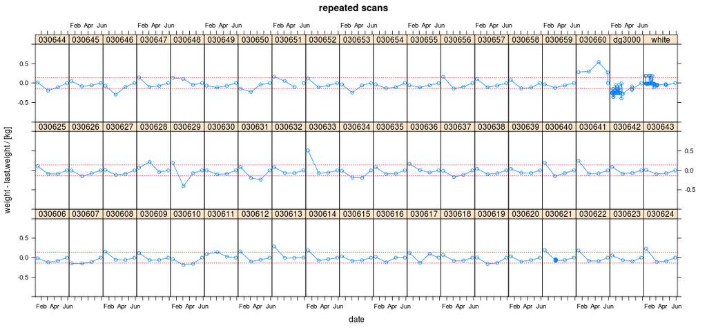

Initially 030651 (and maybe 030660) appeared to have changed in weight considerably. After rescanning it became apparent that the first weight measurment for 030651 was grossly in error (~0.7kg lower) and this measurement was deleted from the database.

# Resonance

Based on repeated weights of the wooden calibration beam (dg3000), an estimate of the standard error for the weight measurement is 2 Hz. In the plot below the red dotted lines indicate the 95% limits (assuming weight errors normally distributed).

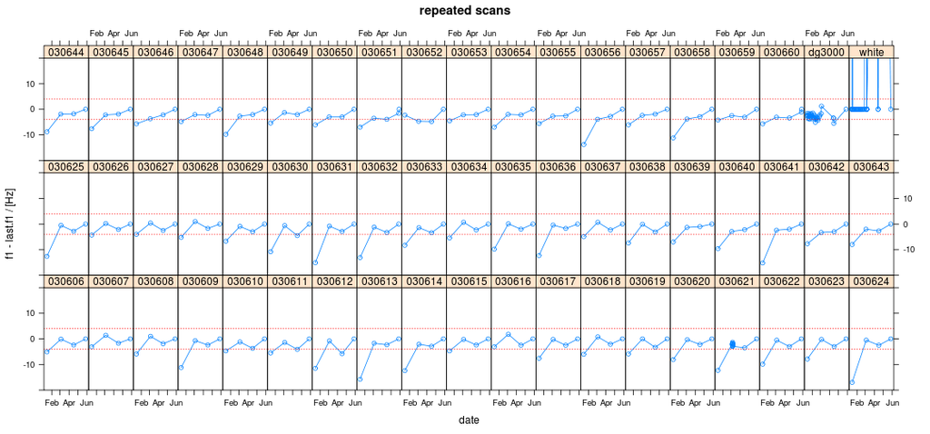

Based on resonance measurments, all boards appear to have reached equilibrium.

# Crook

Crook is probably the warp measure least affected by how the boards are stacked between measurments.

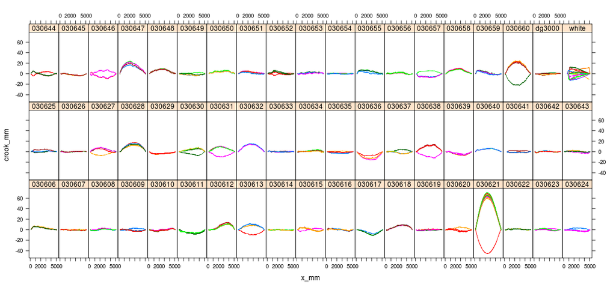

Despite the boards being marked, some warp scans have the boards oriented differently. To fix this introduce a ''rotX'' field into the database and manually estimate it based on the warp profile data. Having done that, the warp data can be corrected:

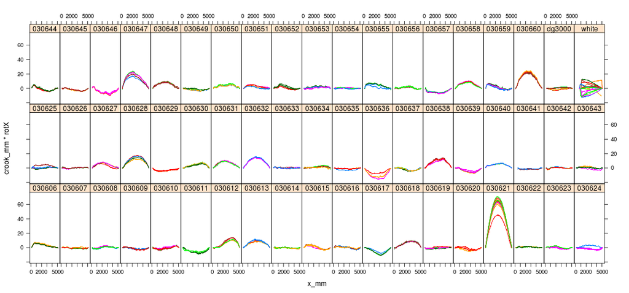

Repeated measurements suggest the mid-point crook estimate has a standard error of around 1 mm.

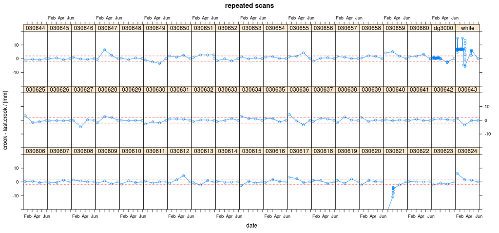

Around 15% (8/57) of the boards appear **not** to have reached a stable crook.

# Bow

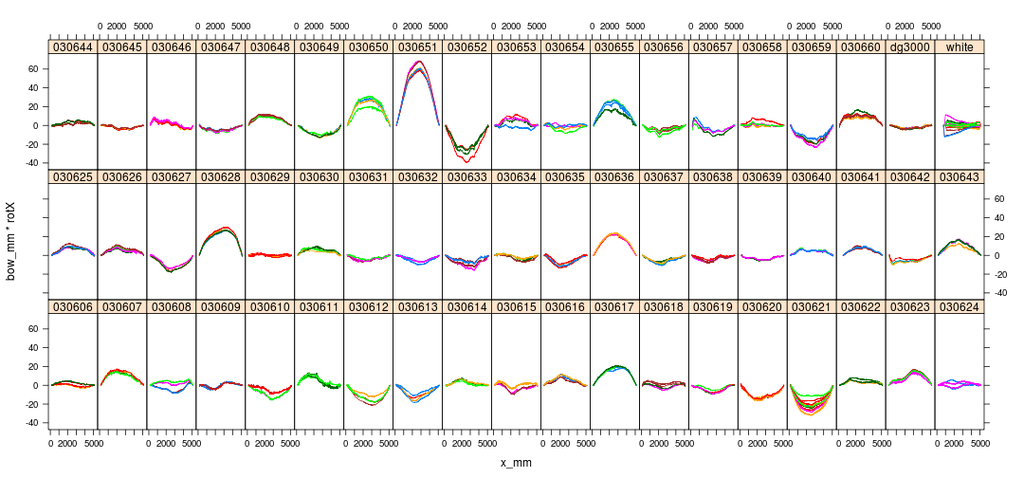

Mid-point bow appears to have a similar repeatability as mid-point crook, i.e. 1 mm.

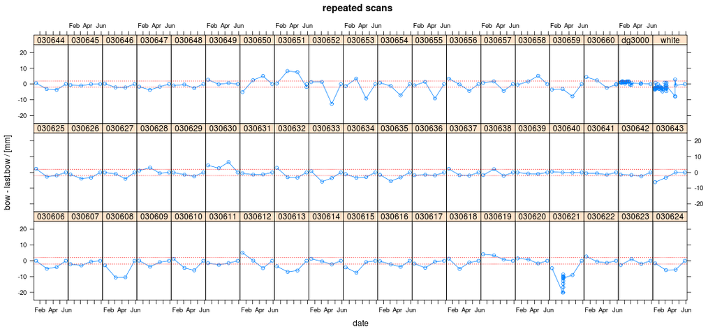

Around 30% (17/57) of the boards do **not** appear to have reached a stable bow.